# Task 4.1 Supervised Learning - Regression

Modul 12: Application of Machine Learning in Health Care

Author:** Markus Schwaiger

Date:** May 3, 2024

- Load dataset heartdata.csv
- Check assumptions of a linear regression model (use R functions cor.test and hist and plot), see also Linear Regression in R | An Easy Step-by-Step Guide (scribbr.com)
- Fit a linear regression model (use R function lm)
- Evaluate the model (R function summary and plot)
- Train the model using R function train of package caret
- Update your git-repository.

```r
require(ggplot2)
require(caret)
```

# Load dataset heartdata.csv

```r
data <- read.csv("../data/heartdata.csv", row.names = 1) # first column is used as row names
head(data)
```

```
##      biking   smoking heartdisease
## 1 30.801246 10.896608    11.769423
## 2 65.129215  2.219563     2.854081
## 3  1.959665 17.588331    17.177803
## 4 44.800196  2.802559     6.816647
## 5 69.428454 15.974505     4.062224
## 6 54.403626 29.333176     9.550046
```

```r
dim(data)
```

```
## [1] 498   3
```

```r
sum(is.na(data))
```

```
## [1] 0
```

# Check assumptions of a linear regression model

### Correlation between biking and smoking (independent variables)

```r
correlation <- cor.test(data$biking, data$smoking)
cat("The correlation between biking and smoking is:",correlation$estimate*100,"%")
```

```
## The correlation between biking and smoking is: 1.513618 %
```

- The correlation between biking and smoking is small, so we can include both parameters in our model.

### Normality

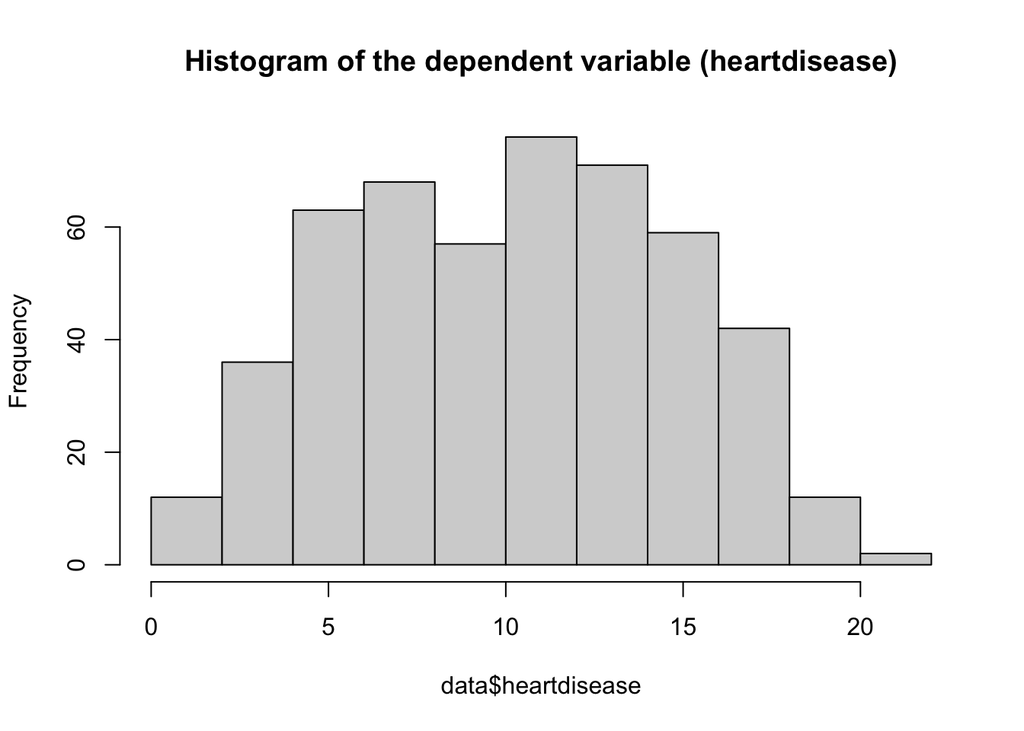

```r
hist(data$heartdisease, main = "Histogram of the dependent variable (heartdisease)")
```

- The distribution is a bell curve, so we can proceed with linear regression.

### Linearity

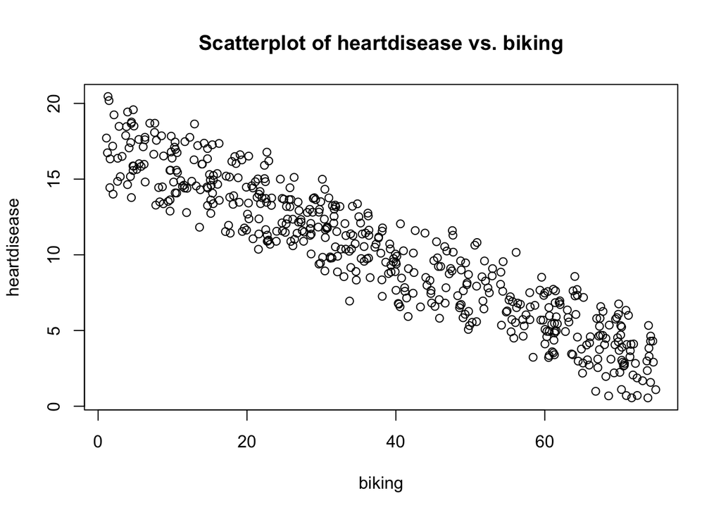

```r
plot(heartdisease ~ biking, data=data, main = "Scatterplot of heartdisease vs. biking")
```

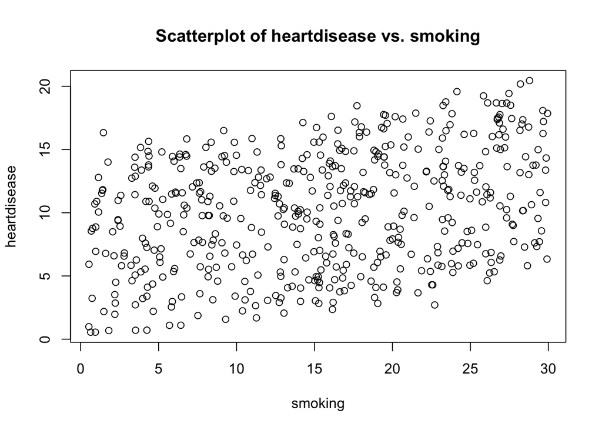

```r
plot(heartdisease ~smoking, data=data, main = "Scatterplot of heartdisease vs. smoking")
```

- Both variables display a linear relationship, so we can proceed with linear regression.

# Fit and evaluate a linear regression model

```r
hd_lm <- lm(heartdisease ~ ., data = data)
hd_lm
```

```
##
## Call:
## lm(formula = heartdisease ~ ., data = data)
##
## Coefficients:
## (Intercept)       biking      smoking
##     14.9847      -0.2001       0.1783
```

```r
summary(hd_lm)
```

```
##
## Call:
## lm(formula = heartdisease ~ ., data = data)
##
## Residuals:
##     Min      1Q  Median      3Q     Max
## -2.1789 -0.4463  0.0362  0.4422  1.9331
##
## Coefficients:
##              Estimate Std. Error t value Pr(>|t|)
## (Intercept) 14.984658   0.080137  186.99   <2e-16 ***
## biking      -0.200133   0.001366 -146.53   <2e-16 ***
## smoking      0.178334   0.003539   50.39   <2e-16 ***
## ---
## Signif. codes:  0 '***' 0.001 '**' 0.01 '*' 0.05 '.' 0.1 ' ' 1
##
## Residual standard error: 0.654 on 495 degrees of freedom
## Multiple R-squared:  0.9796, Adjusted R-squared:  0.9795
## F-statistic: 1.19e+04 on 2 and 495 DF,  p-value: < 2.2e-16
```

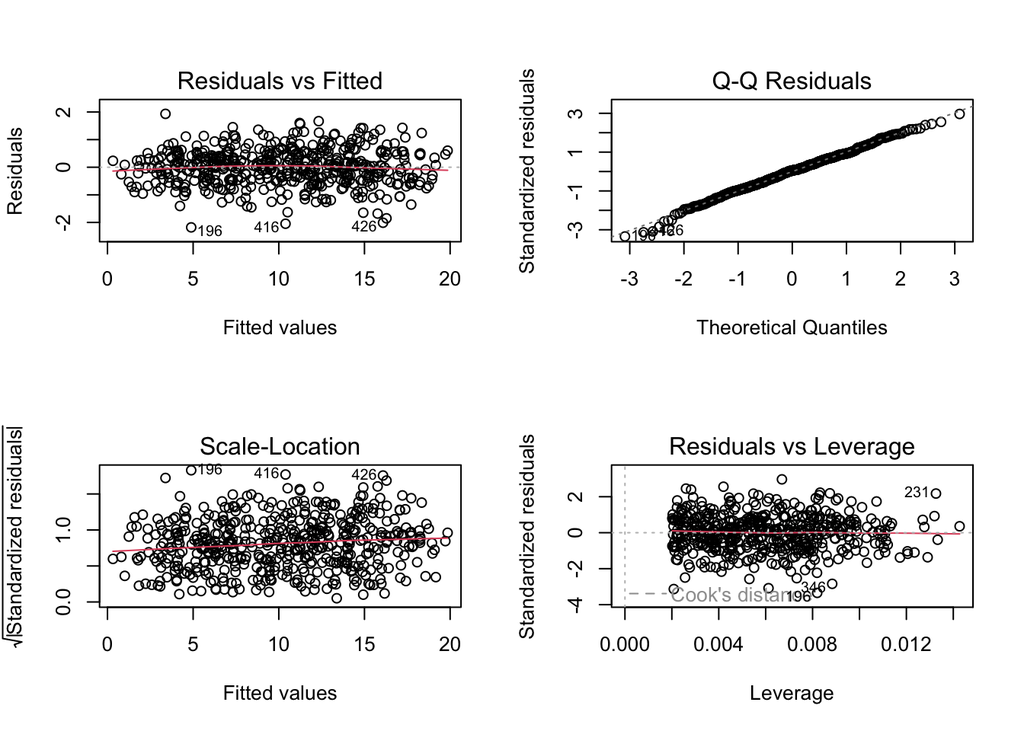

```r
par(mfrow=c(2,2))
plot(hd_lm)
```

- An 1% increase in biking is associated with a 0.2001% decrease in the rate of heart disease
- An 1% increase in smoking is associated with an 0.1783% increase in the rate of heart disease
- Both p-values indicate a highly significance.
- The residuals show no bias, so we can say our model fits the assumption of homoscedasticity.

# Visualization of the model

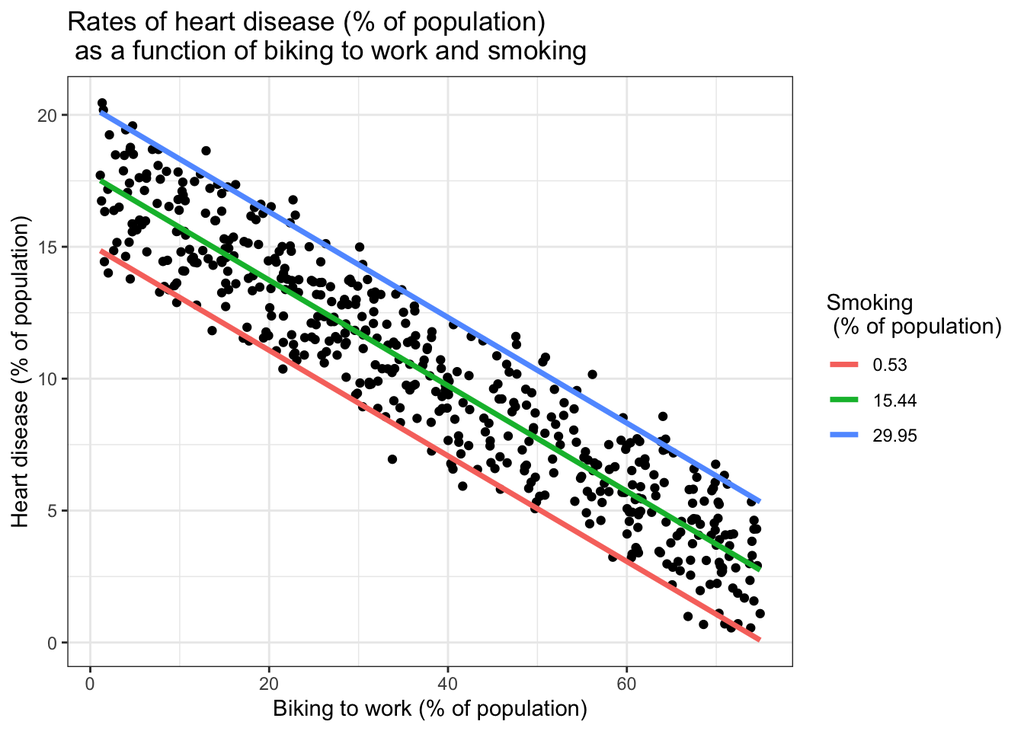

```r
plotting.data <- expand.grid(
  biking = seq(min(data$biking), max(data$biking), length.out=30),
  smoking=c(min(data$smoking), mean(data$smoking),max(data$smoking)))
plotting.data$predicted.y <- predict.lm(hd_lm, newdata = plotting.data)
plotting.data$smoking <- round(plotting.data$smoking, digits = 2)
plotting.data$smoking <- as.factor(plotting.data$smoking)
heart.plot <- ggplot(data, aes(x=biking, y=heartdisease)) +
  geom_point() +
  geom_line(data=plotting.data, aes(x=biking, y=predicted.y, color=smoking), linewidth=1.25) +
  theme_bw() +
  labs(title = "Rates of heart disease (% of population) \n as a function of biking to work and smoking",
      x = "Biking to work (% of population)",
      y = "Heart disease (% of population)",
      color = "Smoking \n (% of population)")

heart.plot
```

# Train the model

```r
set.seed(123)
fitControl <- trainControl(method="cv",number =10)
lmFit <- train(heartdisease ~., data=data, method = "lm", preProc=c("center","scale"), trControl = fitControl)
lmFit
```

```
## Linear Regression
##
## 498 samples
##   2 predictor
##
## Pre-processing: centered (2), scaled (2)
## Resampling: Cross-Validated (10 fold)
## Summary of sample sizes: 447, 449, 449, 448, 448, 450, ...
## Resampling results:
##
##   RMSE       Rsquared  MAE
##   0.6521001  0.980434  0.5191487
##
## Tuning parameter 'intercept' was held constant at a value of TRUE
```